# Marketing mix: warped adstock effects

Sparse marketing pulses are fine to soft-warp **after** an adstock transform, with two optional constraints:

1. **Pulse-start pins** — each spend onset stays fixed (`p[i]=i`); the path may stretch or compress between onsets.
2. **Terror masking** — when raw spend is off, those indices contribute little to the terror likelihood.

This notebook builds $y$ as **trend + seasonal + noise + warped media**, then recovers all of those pieces with a fully Bayesian dual model (same stack as `4_Fully_Bayesian.ipynb`): unwarped trend/season amplitudes, media amplitude $A_m$, warp path $p$, and terror scale $\sigma_t$.

Theory for dual / terror loss: `1_Introduction_to_Warp_Regression.ipynb`.

```python
%matplotlib inline
import sys
from pathlib import Path

for _p in (Path.cwd().resolve().parents[1] / "src", Path.cwd().resolve().parent):
    s = str(_p)
    if _p.is_dir() and s not in sys.path:
        sys.path.insert(0, s)

import arviz as az
import jax.numpy as jnp
import matplotlib.pyplot as plt
import numpy as np
import pymc as pm
import torch
import torch.nn as nn
from pymc.sampling.jax import sample_numpyro_nuts

from warp_regression import (
    WarpPath,
    geometric_adstock,
    pulse_start_indices,
    soft_warp_numpy,
    terror_mask_from_values,
)
from warp_regression.core.bayesian_jax import (
    make_dual_logp_op,
    path_from_B,
    pins_parameter_size,
    predict_from_params,
    soft_warp,
    terror_likelihood,
)
from warp_regression.core.path import (
    allocate_interval_knots,
    normalize_pins,
    path_from_B_torch,
)
from warp_regression.core.training import compute_dual_loss
from warp_regression.core.warp import soft_warp_torch

plt.rcParams.update({"figure.figsize": (10, 3.2), "axes.grid": True, "grid.alpha": 0.3})
rng = np.random.default_rng(7)
torch.manual_seed(7)
```

```
<torch._C.Generator at 0x1415d7990>
```

## 1. Simulated baseline + four spend impulses

Generate length-$n$ outcome as the sum of:

1. **Trend** — GP with a quadratic (degree-2 polynomial) kernel.
2. **Seasonal** — GP with a periodic kernel.
3. **Remainder noise** — light i.i.d. Gaussian.
4. **Marketing** — **four** unit-time spend impulses → geometric adstock → known warp under pulse pins → $A_m \cdot \mathrm{warp}(\mathrm{adstock}, p_{\mathrm{true}})$.

The true path puts a non-zero offset bump in **every** inter-pin interval, so each adstock tail is warped (standard pinned-bridge geometry, not a post-hoc clamp).

```python
def gp_sample(K: np.ndarray, rng: np.random.Generator) -> np.ndarray:
    K = 0.5 * (K + K.T) + 1e-6 * np.eye(K.shape[0])
    return np.linalg.cholesky(K) @ rng.normal(size=K.shape[0])


def quadratic_kernel(t: np.ndarray, sigma: float = 1.0, c: float = 1.0) -> np.ndarray:
    x = (t - t.mean()) / max(t.std(), 1.0)
    return (sigma**2) * (c + np.outer(x, x)) ** 2


def periodic_kernel(
    t: np.ndarray, period: float, length: float = 1.2, sigma: float = 1.0
) -> np.ndarray:
    dt = t[:, None] - t[None, :]
    return (sigma**2) * np.exp(
        -2.0 * np.sin(np.pi * np.abs(dt) / period) ** 2 / (length**2)
    )


def b_true_warps_every_interval(n: int, n_knots: int, pins, amps) -> np.ndarray:
    # Knot coeffs so each pin-to-pin bridge has a mid-segment offset bump.
    pin_arr = normalize_pins(pins, n)
    pin_set = set(int(i) for i in pin_arr.tolist())
    cuts = [0] + [i for i in pin_arr.tolist() if i not in (0, n - 1)] + [n - 1]
    cuts = sorted(set(cuts))
    intervals = []
    for a, b in zip(cuts[:-1], cuts[1:]):
        if b > a:
            trailing_open = b == n - 1 and (n - 1) not in pin_set
            intervals.append((a, b, not trailing_open))
    lengths = [b - a + 1 for a, b, _ in intervals]
    knot_counts = allocate_interval_knots(lengths, n_knots)
    b = np.zeros(int(sum(knot_counts)), dtype=np.float64)
    cursor = 0
    for k_i, amp in zip(knot_counts, amps):
        # Both-ends-pinned bridge: a half-sine in B makes a clear mid-interval bump.
        # Needs k_i >= 3; with only 2 knots both-end pinning forces offset ≡ 0.
        b[cursor : cursor + k_i] = float(amp) * np.sin(np.linspace(0.0, np.pi, k_i))
        cursor += k_i
    return b


n, n_knots = 160, 20  # enough knots so every pin bridge gets >=3 (can bend)
LAM = 0.5
NOISE_STD = 0.12
A_M_TRUE = 1.8
A_TREND_TRUE = 1.0
A_SEASON_TRUE = 1.0
C_TRUE = 0.0
ALPHA = 0.90  # long adstock tail so warp of the decay is visible
t = np.arange(n, dtype=np.float64)

trend = gp_sample(quadratic_kernel(t, sigma=0.9, c=1.0), rng)
seasonal = gp_sample(periodic_kernel(t, period=20.0, length=1.0, sigma=1.0), rng)
noise = NOISE_STD * rng.normal(size=n)

# Exactly four spend impulses (one pin each).
spend = np.zeros(n)
spend[[20, 55, 95, 125]] = [1.4, 1.2, 1.1, 1.0]

adstock = geometric_adstock(spend, ALPHA)
pins = pulse_start_indices(spend)
terror_mask = terror_mask_from_values(spend)
# Soft floor for Bayesian / terror MLE: hard zeros create a NUTS funnel.
terror_mask_bayes = np.where(terror_mask, 1.0, 0.05)
b_dim = pins_parameter_size(n, n_knots, pins)

# Moderate stretch/compress bumps on every bridge (visible, not pathological).
B_TRUE = b_true_warps_every_interval(
    n, n_knots, pins, amps=[2.5, -3.0, 2.8, -2.7, 3.0]
)
path_true = WarpPath(n, n_knots, pins=pins, B_init=B_TRUE)
with torch.no_grad():
    p_true = path_true.path().detach().numpy()

# Reference terror scale on the true path (soft-masked).
p_off_true = p_true - np.arange(n)
sig_grid = np.linspace(0.05, 4.0, 200)
terror_vals = [
    float(
        terror_likelihood(
            jnp.asarray(p_off_true),
            float(s),
            n_knots,
            mask=jnp.asarray(terror_mask_bayes, dtype=jnp.float64),
        )
    )
    for s in sig_grid
]
SIGMA_T_TRUE = float(sig_grid[int(np.argmax(terror_vals))])

media_true = A_M_TRUE * soft_warp_numpy(adstock, p_true)
baseline_true = C_TRUE + A_TREND_TRUE * trend + A_SEASON_TRUE * seasonal
y = baseline_true + media_true + noise

# Unwarped covariates the model recovers jointly with the media warp.
T = np.column_stack([np.ones(n), trend, seasonal])
beta_true = np.array([C_TRUE, A_TREND_TRUE, A_SEASON_TRUE], dtype=np.float64)

print(f"n={n}  pins={pins.tolist()}  alpha={ALPHA}  A_m={A_M_TRUE}")
print(f"B dim={b_dim}  sigma_t_true≈{SIGMA_T_TRUE:.3f}")
print(f"pin check max |p[i]-i| = {np.max(np.abs(p_true[pins] - pins)):.2e}")
for a, b in zip(pins.tolist(), list(pins.tolist()[1:]) + [n - 1]):
    mid = (a + b) // 2
    print(f"  offset mid[{a},{b}] @ {mid}: {p_true[mid] - mid:+.2f}")
```

```
n=160  pins=[20, 55, 95, 125]  alpha=0.9  A_m=1.8
B dim=20  sigma_t_true≈0.209
pin check max |p[i]-i| = 0.00e+00
  offset mid[20,55] @ 37: -2.67
  offset mid[55,95] @ 75: +1.81
  offset mid[95,125] @ 110: -2.34
  offset mid[125,159] @ 142: +1.30
```

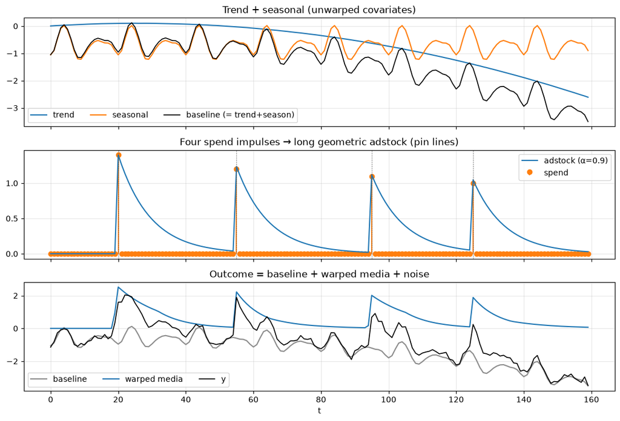

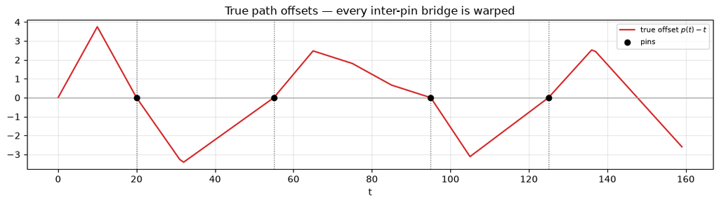

```python
fig, axes = plt.subplots(3, 1, figsize=(11, 7.5), sharex=True)
axes[0].plot(t, trend, label="trend")
axes[0].plot(t, seasonal, label="seasonal")
axes[0].plot(t, baseline_true, color="k", lw=1.2, label="baseline (= trend+season)")
axes[0].legend(ncol=3)
axes[0].set_title("Trend + seasonal (unwarped covariates)")

axes[1].stem(t, spend, linefmt="C1-", markerfmt="C1o", basefmt=" ", label="spend")
axes[1].plot(t, adstock, color="C0", label=f"adstock (α={ALPHA})")
for i in pins:
    axes[1].axvline(i, color="0.35", ls=":", lw=0.9)
axes[1].legend()
axes[1].set_title("Four spend impulses → long geometric adstock (pin lines)")

axes[2].plot(t, baseline_true, color="0.55", label="baseline")
axes[2].plot(t, media_true, label="warped media")
axes[2].plot(t, y, color="k", lw=1.2, label="y")
axes[2].legend(ncol=3)
axes[2].set_title("Outcome = baseline + warped media + noise")
axes[2].set_xlabel("t")
plt.tight_layout()

fig, ax = plt.subplots(figsize=(11, 3.2))
ax.plot(t, p_true - t, color="C3", lw=1.6, label="true offset $p(t)-t$")
ax.axhline(0.0, color="0.6", lw=0.8)
for i in pins:
    ax.axvline(i, color="0.35", ls=":", lw=0.9)
ax.scatter(pins, np.zeros(len(pins)), c="k", s=36, zorder=5, label="pins")
ax.set_title("True path offsets — every inter-pin bridge is warped")
ax.set_xlabel("t")
ax.legend(fontsize=8)
plt.tight_layout()
```

## 2. MAP warm-start

Observation model (realism check):

$$\hat{y} = C + A_{\mathrm{trend}}\,\mathrm{trend} + A_{\mathrm{season}}\,\mathrm{seasonal} + A_m \cdot \mathrm{warp}(\mathrm{adstock}, p).$$

Trend and seasonal enter as **known unwarped covariates** with free amplitudes — the media path is what absorbs timing. Soft terror mask (`1` on spend, `0.05` off) keeps NUTS well-behaved.

```python
x_t = torch.tensor(adstock, dtype=torch.float64)
y_t = torch.tensor(y, dtype=torch.float64)
T_t = torch.tensor(T, dtype=torch.float64)

B_t = nn.Parameter(torch.zeros(b_dim, dtype=torch.float64))
A_t = nn.Parameter(torch.tensor(1.0, dtype=torch.float64))
beta_t = nn.Parameter(torch.tensor([0.0, 0.5, 0.5], dtype=torch.float64))
log_sy = nn.Parameter(torch.tensor(np.log(0.3), dtype=torch.float64))
log_st = nn.Parameter(torch.tensor(np.log(1.0), dtype=torch.float64))
opt = torch.optim.Adam([B_t, A_t, beta_t, log_sy, log_st], lr=0.05)

for _ in range(4000):
    opt.zero_grad()
    p_t = path_from_B_torch(B_t, n, n_knots, pins=pins)
    y_hat = A_t * soft_warp_torch(x_t, p_t) + T_t @ beta_t
    loss, _ = compute_dual_loss(
        y_t,
        y_hat,
        p_t,
        log_sy,
        log_st,
        n_knots,
        LAM,
        terror_mask=terror_mask_bayes,
    )
    loss.backward()
    opt.step()

map_init = {
    "B": B_t.detach().numpy().copy(),
    "A_m": np.array(float(A_t.detach())),
    "beta": beta_t.detach().numpy().copy(),
    "sigma_y": np.array(float(torch.exp(log_sy).detach())),
    "sigma_t": np.array(float(torch.exp(log_st).detach())),
}
print(
    f"MAP  A_m={map_init['A_m']:.3f}  "
    f"beta={np.round(map_init['beta'], 3)}  "
    f"σ_y={map_init['sigma_y']:.3f}  σ_t={map_init['sigma_t']:.3f}"
)
print(f"true A_m={A_M_TRUE}  beta={beta_true}  σ_t≈{SIGMA_T_TRUE:.3f}")
```

```
MAP  A_m=1.845  beta=[-0.016  1.004  0.986]  σ_y=0.108  σ_t=0.212
true A_m=1.8  beta=[0. 1. 1.]  σ_t≈0.209
```

## 3. Fully Bayesian dual model

Priors on $B$, $A_m$, baseline amplitudes $\beta=(C, A_{\mathrm{trend}}, A_{\mathrm{season}})$, and scales $\sigma_y$, $\sigma_t$. Dual potential at $\lambda=0.5$ with pins + soft terror mask.

```python
dual_op, _ = make_dual_logp_op(
    adstock,
    y,
    n_knots=n_knots,
    lam=LAM,
    pins=pins,
    terror_mask=terror_mask_bayes,
    baseline=T,
)

with pm.Model() as model:
    B = pm.Normal("B", mu=0.0, sigma=30.0, shape=b_dim)
    A_m = pm.Normal("A_m", mu=1.0, sigma=2.0)
    beta = pm.Normal("beta", mu=0.0, sigma=2.0, shape=T.shape[1])
    sigma_y = pm.HalfNormal("sigma_y", sigma=0.5)
    sigma_t = pm.HalfNormal("sigma_t", sigma=1.5)
    pm.Potential("dual", dual_op(B, A_m, beta, sigma_y, sigma_t))

model
```

$$ \begin{array}{rcl} \text{B} &\sim & \operatorname{Normal}(0,~30)\\\text{A\_m} &\sim & \operatorname{Normal}(1,~2)\\\text{beta} &\sim & \operatorname{Normal}(0,~2)\\\text{sigma\_y} &\sim & \operatorname{HalfNormal}(0,~0.5)\\\text{sigma\_t} &\sim & \operatorname{HalfNormal}(0,~1.5)\\\text{dual} &\sim & \operatorname{Potential}(f(\text{B},~\text{A\_m},~\text{beta},~\text{sigma\_y},~\text{sigma\_t})) \end{array} $$

## 4. Sample and check parameter recovery

```python
with model:
    idata = sample_numpyro_nuts(
        draws=800,
        tune=1000,
        chains=4,
        target_accept=0.95,
        random_seed=11,
        progressbar=True,
        initvals=map_init,
    )

print(az.summary(idata, var_names=["A_m", "beta", "sigma_y", "sigma_t"], round_to=3))
print()
for name, truth in (
    ("A_m", A_M_TRUE),
    ("sigma_y", NOISE_STD),
    ("sigma_t", SIGMA_T_TRUE),
):
    lo = float(idata.posterior[name].quantile(0.025))
    hi = float(idata.posterior[name].quantile(0.975))
    mu = float(idata.posterior[name].mean())
    print(
        f"{name}: mean={mu:.3f}  95%[{lo:.3f}, {hi:.3f}]  "
        f"true={truth:.3f}  covered={lo <= truth <= hi}"
    )
beta_mean = np.asarray(idata.posterior["beta"].mean(dim=("chain", "draw")))
print(f"beta mean={np.round(beta_mean, 3)}  true={beta_true}")
```

```
The rhat statistic is larger than 1.01 for some parameters. This indicates problems during sampling. See https://arxiv.org/abs/1903.08008 for details
```

```
The effective sample size per chain is smaller than 100 for some parameters.  A higher number is needed for reliable rhat and ess computation. See https://arxiv.org/abs/1903.08008 for details
```

```
          mean     sd  eti89_lb  eti89_ub  ess_bulk  ess_tail  r_hat  \
A_m      1.846  0.032     1.796     1.895   396.185   617.699  1.008
beta[0] -0.015  0.027    -0.058     0.027   244.553   394.332  1.017
beta[1]  1.004  0.017     0.978     1.031   367.159   613.840  1.009
beta[2]  0.986  0.029     0.940     1.032   244.844   364.269  1.025
sigma_y  0.114  0.007     0.104     0.125   375.435   644.341  1.007
sigma_t  0.250  0.064     0.167     0.362   559.744   814.985  1.009

         mcse_mean  mcse_sd
A_m          0.002    0.001
beta[0]      0.002    0.001
beta[1]      0.001    0.001
beta[2]      0.002    0.001
sigma_y      0.000    0.000
sigma_t      0.003    0.003

A_m: mean=1.846  95%[1.784, 1.908]  true=1.800  covered=True
sigma_y: mean=0.114  95%[0.101, 0.128]  true=0.120  covered=True
sigma_t: mean=0.250  95%[0.156, 0.403]  true=0.209  covered=True
beta mean=[-0.015  1.004  0.986]  true=[0. 1. 1.]
```

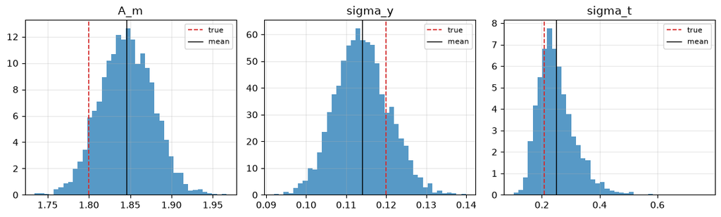

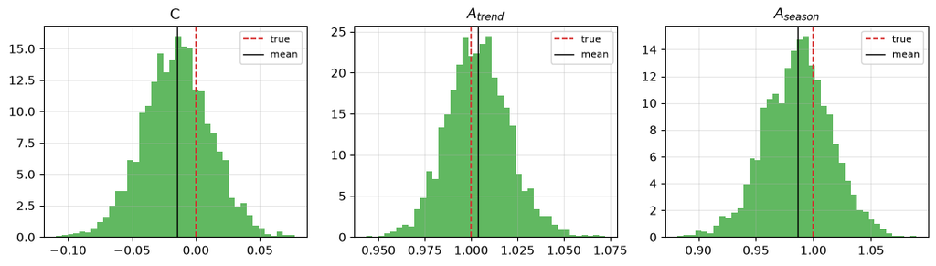

```python
fig, axes = plt.subplots(1, 3, figsize=(11, 3.4))
for ax, name, truth in zip(
    axes,
    ["A_m", "sigma_y", "sigma_t"],
    [A_M_TRUE, NOISE_STD, SIGMA_T_TRUE],
):
    samples = np.asarray(idata.posterior[name]).ravel()
    ax.hist(samples, bins=40, color="C0", alpha=0.75, density=True)
    ax.axvline(truth, color="C3", ls="--", lw=1.2, label="true")
    ax.axvline(samples.mean(), color="k", lw=1.0, label="mean")
    ax.set_title(name)
    ax.legend(fontsize=8)
plt.tight_layout()

fig, axes = plt.subplots(1, 3, figsize=(11, 3.2))
beta_labels = ["C", r"$A_{trend}$", r"$A_{season}$"]
for j, (ax, lab) in enumerate(zip(axes, beta_labels)):
    samples = np.asarray(idata.posterior["beta"][..., j]).ravel()
    ax.hist(samples, bins=40, color="C2", alpha=0.75, density=True)
    ax.axvline(beta_true[j], color="C3", ls="--", lw=1.2, label="true")
    ax.axvline(samples.mean(), color="k", lw=1.0, label="mean")
    ax.set_title(lab)
    ax.legend(fontsize=8)
plt.tight_layout()
```

## 5. Component + warp-path diagnostics

Recovered $\hat{y}$ splits into baseline ($C + A_{\mathrm{trend}}\,\mathrm{trend} + A_{\mathrm{season}}\,\mathrm{seasonal}$) and warped media. Path draws keep the four spend onsets pinned.

```
mean |p_mean - p_true| = 1.105  pin residual = 0.00e+00
baseline RMSE = 0.009  media RMSE = 0.035
```

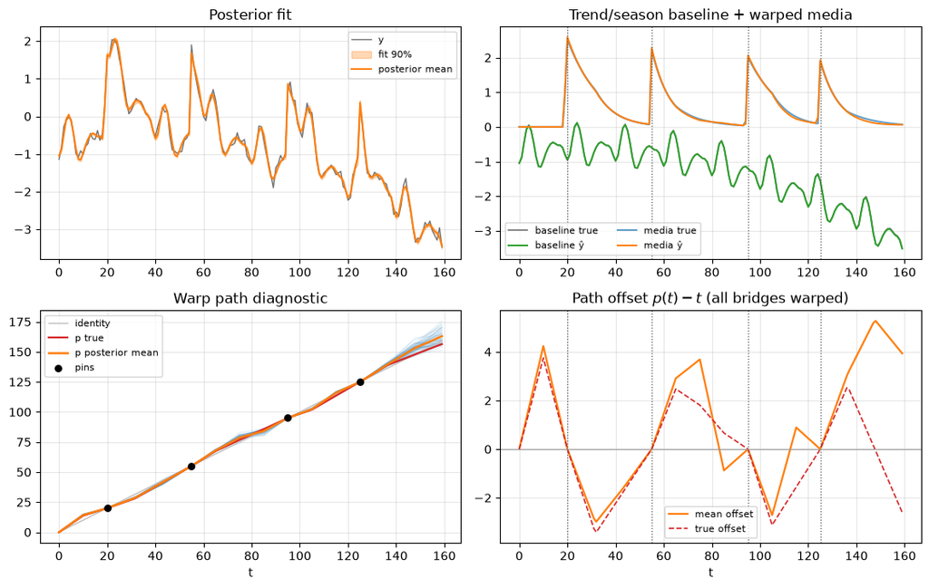

```python
post = idata.posterior
b_dim_name = [d for d in post["B"].dims if d not in ("chain", "draw")][0]
B_s = np.asarray(post["B"].stack(sample=("chain", "draw")).transpose("sample", b_dim_name))
A_s = np.asarray(post["A_m"].stack(sample=("chain", "draw")))
beta_s = np.asarray(
    post["beta"].stack(sample=("chain", "draw")).transpose(
        "sample", [d for d in post["beta"].dims if d not in ("chain", "draw")][0]
    )
)

n_show = min(100, B_s.shape[0])
idx_show = rng.choice(B_s.shape[0], size=n_show, replace=False)

p_samples, media_samples, base_samples, y_hat_samples = [], [], [], []
x_j = jnp.asarray(adstock)
T_j = jnp.asarray(T)
for i in idx_show:
    y_hat_i, p_i = predict_from_params(
        jnp.asarray(B_s[i]),
        float(A_s[i]),
        jnp.asarray(beta_s[i]),
        x_j,
        n_knots,
        pins=pins,
        baseline=T_j,
    )
    p_i = np.asarray(p_i)
    media_i = float(A_s[i]) * np.asarray(soft_warp(x_j, jnp.asarray(p_i)))
    base_i = np.asarray(T_j @ jnp.asarray(beta_s[i]))
    p_samples.append(p_i)
    media_samples.append(media_i)
    base_samples.append(base_i)
    y_hat_samples.append(np.asarray(y_hat_i))

p_samples = np.stack(p_samples)
media_samples = np.stack(media_samples)
base_samples = np.stack(base_samples)
y_hat_samples = np.stack(y_hat_samples)
p_mean = p_samples.mean(axis=0)
media_mean = media_samples.mean(axis=0)
base_mean = base_samples.mean(axis=0)
y_q = np.quantile(y_hat_samples, [0.05, 0.95], axis=0)

fig, axes = plt.subplots(2, 2, figsize=(11, 7.0))

ax = axes[0, 0]
ax.plot(t, y, color="0.45", lw=1.0, label="y")
ax.fill_between(t, y_q[0], y_q[1], color="C1", alpha=0.3, label="fit 90%")
ax.plot(t, y_hat_samples.mean(axis=0), color="C1", lw=1.4, label="posterior mean")
ax.legend(fontsize=8)
ax.set_title("Posterior fit")

ax = axes[0, 1]
ax.plot(t, baseline_true, color="0.45", lw=1.2, label="baseline true")
ax.plot(t, base_mean, color="C2", lw=1.4, label="baseline ŷ")
ax.plot(t, media_true, color="C0", alpha=0.7, label="media true")
ax.plot(t, media_mean, color="C1", lw=1.4, label="media ŷ")
for i in pins:
    ax.axvline(i, color="0.35", ls=":", lw=0.9)
ax.legend(fontsize=8, ncol=2)
ax.set_title("Trend/season baseline + warped media")

ax = axes[1, 0]
for p_i in p_samples[::2]:
    ax.plot(t, p_i, color="C0", alpha=0.12, lw=0.8)
ax.plot(t, t, color="0.75", lw=1.0, label="identity")
ax.plot(t, p_true, color="C3", lw=1.6, label="p true")
ax.plot(t, p_mean, color="C1", lw=1.8, label="p posterior mean")
ax.scatter(pins, pins, c="k", s=28, zorder=5, label="pins")
ax.legend(fontsize=8)
ax.set_title("Warp path diagnostic")
ax.set_xlabel("t")

ax = axes[1, 1]
ax.plot(t, p_mean - t, color="C1", lw=1.6, label="mean offset")
ax.plot(t, p_true - t, color="C3", lw=1.2, ls="--", label="true offset")
for i in pins:
    ax.axvline(i, color="0.35", ls=":", lw=0.9)
ax.axhline(0.0, color="0.6", lw=0.8)
ax.legend(fontsize=8)
ax.set_title("Path offset $p(t)-t$ (all bridges warped)")
ax.set_xlabel("t")

plt.tight_layout()
print(
    f"mean |p_mean - p_true| = {np.mean(np.abs(p_mean - p_true)):.3f}  "
    f"pin residual = {np.max(np.abs(p_mean[pins] - pins)):.2e}"
)
print(
    f"baseline RMSE = {np.sqrt(np.mean((base_mean - baseline_true) ** 2)):.3f}  "
    f"media RMSE = {np.sqrt(np.mean((media_mean - media_true) ** 2)):.3f}"
)
```

## 6. Unit-spend lagged effects under warp-path uncertainty

Posterior $B$ draws are tight once the path is identified — that is why a spaghetti of $\mathrm{warp}(\mathrm{adstock}, p(B))$ looks like one curve.

What we want for **effect-length uncertainty** is different: sample **terror-scale random-walk / Brownian-bridge** realizations of $p$ (pins fixed, base = posterior-mean path, step scale from $\sigma_t$), then soft-warp a unit spend's adstock under each draw.

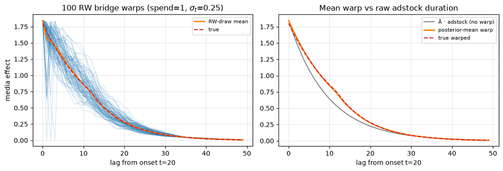

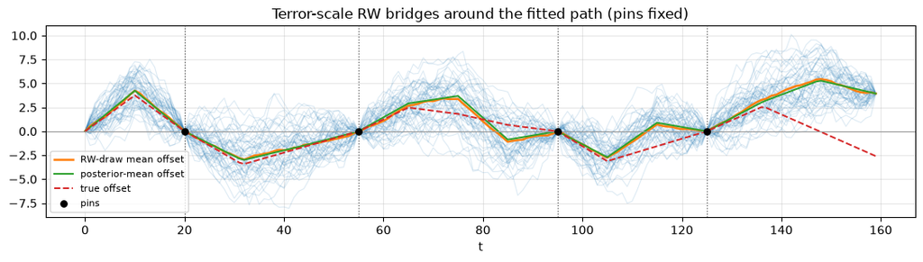

```python
from warp_regression.forecast.paths import per_index_rw_sigma


def sample_pinned_bridge_paths(
    p_base: np.ndarray,
    pins,
    sigma_t: float,
    n_knots: int,
    n_paths: int,
    *,
    seed: int = 0,
) -> np.ndarray:
    # RW bridges between pins; endpoints stay on p_base (identity at pins).
    rng = np.random.default_rng(seed)
    n = len(p_base)
    sigma_step = per_index_rw_sigma(float(sigma_t), n, n_knots)
    pin_arr = np.unique(np.asarray(pins, dtype=int))
    cuts = sorted(set([0] + pin_arr.tolist() + [n - 1]))
    base_off = p_base - np.arange(n, dtype=np.float64)
    out = np.zeros((n_paths, n), dtype=np.float64)
    for k in range(n_paths):
        off = base_off.copy()
        for a, b in zip(cuts[:-1], cuts[1:]):
            n_seg = b - a + 1
            if n_seg <= 2:
                continue
            w = np.cumsum(rng.normal(0.0, sigma_step, size=n_seg))
            w = w - w[0]
            tt = np.linspace(0.0, 1.0, n_seg)
            bridge = w - tt * w[-1]  # Brownian bridge residual, ends at 0
            off[a : b + 1] = base_off[a : b + 1] + bridge
        p = np.arange(n, dtype=np.float64) + off
        for i in pin_arr:
            p[i] = float(i)
        p[0] = 0.0
        out[k] = p
    return out


n_imp = 100
onset = int(pins[0])
horizon = 50
A_bar = float(A_s.mean())
# Use posterior-mean path as the bridge center; σ_t from posterior mean.
p_base = p_mean
sigma_t_bar = float(np.asarray(post["sigma_t"]).mean())

impulse = np.zeros(n)
impulse[onset] = 1.0
adstock_imp = geometric_adstock(impulse, ALPHA)

path_draws = sample_pinned_bridge_paths(
    p_base, pins, sigma_t_bar, n_knots, n_imp, seed=21
)
effects = np.stack(
    [A_bar * soft_warp_numpy(adstock_imp, p_i) for p_i in path_draws]
)
eff_true = A_M_TRUE * soft_warp_numpy(adstock_imp, p_true)
eff_base = A_bar * soft_warp_numpy(adstock_imp, p_base)

lag = np.arange(horizon)
fig, axes = plt.subplots(1, 2, figsize=(11, 3.8))

ax = axes[0]
for e in effects:
    ax.plot(lag, e[onset : onset + horizon], color="C0", alpha=0.18, lw=0.9)
ax.plot(
    lag,
    effects.mean(axis=0)[onset : onset + horizon],
    color="C1",
    lw=2.0,
    label="RW-draw mean",
)
ax.plot(lag, eff_true[onset : onset + horizon], color="C3", ls="--", lw=1.6, label="true")
ax.set_xlabel(f"lag from onset t={onset}")
ax.set_ylabel("media effect")
ax.set_title(rf"100 RW bridge warps (spend=1, $\sigma_t$={sigma_t_bar:.2f})")
ax.legend(fontsize=8)

ax = axes[1]
ax.plot(
    lag,
    A_bar * adstock_imp[onset : onset + horizon],
    color="0.5",
    lw=1.4,
    label="Ā · adstock (no warp)",
)
ax.plot(
    lag,
    eff_base[onset : onset + horizon],
    color="C1",
    lw=2.0,
    label="posterior-mean warp",
)
ax.plot(lag, eff_true[onset : onset + horizon], color="C3", ls="--", lw=1.6, label="true warped")
ax.set_xlabel(f"lag from onset t={onset}")
ax.set_title("Mean warp vs raw adstock duration")
ax.legend(fontsize=8)

plt.tight_layout()

fig, ax = plt.subplots(figsize=(11, 3.2))
for p_i in path_draws[::2]:
    ax.plot(t, p_i - t, color="C0", alpha=0.15, lw=0.8)
ax.plot(t, path_draws.mean(axis=0) - t, color="C1", lw=1.8, label="RW-draw mean offset")
ax.plot(t, p_base - t, color="C2", lw=1.4, label="posterior-mean offset")
ax.plot(t, p_true - t, color="C3", ls="--", lw=1.4, label="true offset")
for i in pins:
    ax.axvline(i, color="0.35", ls=":", lw=0.9)
ax.axhline(0.0, color="0.6", lw=0.8)
ax.scatter(pins, np.zeros(len(pins)), c="k", s=28, zorder=5, label="pins")
ax.set_title(r"Terror-scale RW bridges around the fitted path (pins fixed)")
ax.set_xlabel("t")
ax.legend(fontsize=8)
plt.tight_layout()
```

## Takeaways

1. Warp the **already adstocked** series; pass optional `pins` / `terror_mask` from raw spend.
2. Trend and seasonal are recovered as **unwarped** amplitudes; media timing lives in $p$ and $A_m$.
3. Four spend onsets stay pinned; every inter-pin bridge is warped in the generative path.
4. **Effect-length bands** come from terror-scale RW bridge draws of $p$, not from the tight posterior on $B$.